# Homework 1

# Part 1:

Link to discover the first discussion Gemini 3.1 Pro 2 : https://share.gemini.google/mQVoQ6oey1LJ. In the second answer, the AI is detailing more thoroughly the methodology of the semi-variogram and Moran’s I, this is necessary to understand what allows us to affirm or not that the data are spatially dependent.

# Part 2:

## Installation of the packages

The packages only need to be installed once, so this chunk is not evaluated when rendering.

```r
install.packages("geoR")
install.packages("sf")
install.packages("gstat")
install.packages("MBA")
```

## Loading the data

```r
library(geoR)
data(wolfcamp)
```

We got wolfcamp data. In a first time, the data are summarized and plotted in order to understand their distribution.

```r
summary(wolfcamp)
```

```
Number of data points: 85

Coordinates summary
      Coord.X   Coord.Y
min -233.7217 -145.7884
max  181.5314  136.4061

Distance summary
        min         max
  0.3669819 436.2067085

Data summary
     Min.   1st Qu.    Median      Mean   3rd Qu.      Max.
 312.1095  471.8218  547.7156  610.2845  774.1778 1088.4209
```

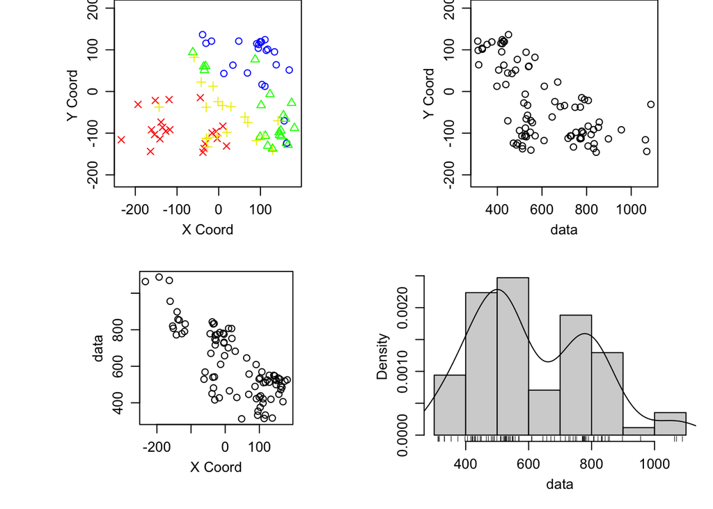

```r
plot(wolfcamp)
```

## Question A): Choice of the smoothness parameter for IDW

A leave one out cross validation is a good way to choose the optimal smoothness parameter in terms of MSE. This prompt was used with using Claude sonnet 5.5 to generate a code for applying this methodoloy:

> I am a student in spatial statistics, I am working on the wolfcamp geodata. Write an R function that choose the best parameter p in Inverse Distance Weighting by leave one out validation evaluated by MSE. You should use the idw implemented in gstat and let me a way to assess choice of p (by returning a plot of the mse according to the different values of p).

```r
library(gstat)
library(sf)
library(ggplot2)

#' Choose the IDW power parameter p by leave-one-out cross-validation (MSE)
#'
#' @param coords  n x 2 matrix/data.frame of coordinates
#' @param z       numeric vector of length n (observed values)
#' @param p_grid  candidate values of the power parameter p (idp in gstat)
#' @param nmax    optional: max number of neighbours used by idw (default: all)
#' @return list with best_p, mse table, and a ggplot object

choose_idw_p <- function(coords, z,
                         p_grid = seq(0.5, 6, by = 0.25),
                         nmax = Inf) {

  stopifnot(nrow(coords) == length(z))
  n <- length(z)

  dat <- data.frame(x = coords[, 1], y = coords[, 2], z = z)
  pts <- st_as_sf(dat, coords = c("x", "y"), crs = NA)

  # LOO predictions for a given p
  loo_mse <- function(p) {
    pred <- numeric(n)
    for (i in seq_len(n)) {
      out <- idw(z ~ 1,
                 locations = pts[-i, ],
                 newdata   = pts[i, ],
                 idp       = p,
                 nmax      = nmax,
                 debug.level = 0)
      pred[i] <- out$var1.pred
    }
    mean((z - pred)^2)
  }

  mse <- vapply(p_grid, loo_mse, numeric(1))
  res <- data.frame(p = p_grid, MSE = mse)
  best_p <- res$p[which.min(res$MSE)]

  plt <- ggplot(res, aes(p, MSE)) +
    geom_line() +
    geom_point() +
    geom_point(data = res[res$p == best_p, ], colour = "red", size = 3) +
    geom_vline(xintercept = best_p, linetype = "dashed", colour = "red") +
    labs(title = "Leave-one-out MSE for IDW",
         subtitle = paste0("Best p = ", best_p,
                           " (MSE = ", signif(min(res$MSE), 4), ")"),
         x = "Power parameter p", y = "LOO MSE") +
    theme_minimal()

  list(best_p = best_p, mse = res, plot = plt)
}
```

Now that the function is created, let’s apply it to wolfcamp data:

```r
library(geoR)
data(wolfcamp)

out <- choose_idw_p(coords = wolfcamp$coords,
                    z      = wolfcamp$data,
                    p_grid = seq(0.5, 6, by = 0.25))

out$best_p   # optimal p
```

```
[1] 3.75
```

```r
out$mse      # table of p vs MSE
```

```
      p       MSE
1  0.50 23042.854
2  0.75 17505.897
3  1.00 13097.774
4  1.25  9953.462
5  1.50  7852.567
6  1.75  6494.728
7  2.00  5626.494
8  2.25  5071.685
9  2.50  4717.988
10 2.75  4495.680
11 3.00  4360.707
12 3.25  4284.191
13 3.50  4246.664
14 3.75  4234.845
15 4.00  4239.666
16 4.25  4254.957
17 4.50  4276.545
18 4.75  4301.632
19 5.00  4328.362
20 5.25  4355.524
21 5.50  4382.351
22 5.75  4408.372
23 6.00  4433.314
```

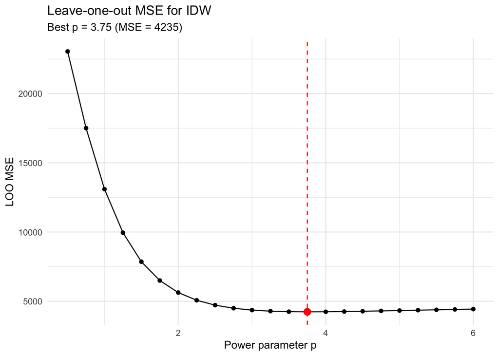

```r
out$plot     # MSE curve
```

The optimal parameter is not on the edge of the values taken by p, thus there is no need to expand the grid and retry. The function states that the MSE is at its lowest when p takes the value of 3.75. This is then retained as the best smoothness parameter in that example.

## Question B): Comparison of IDW and splines

Another interpolation method is the use of multilevel bi-splines, the goal of this code is to compare the efficiency of the two methods. This Prompt used again with Claude sonnet 5.5 to generate the code:

> I work with wolfcamp data, build a 20x20 grid from the coordinates and compare two methods of interpolation : IDW (use the choose_idw_p() R function we built to choose the optimal p) and multilevel bi-splines (function mba.surf from MBA, mba.points) use cross validation with MSE and MAE to compare the methods and let me assess the results.

```r
library(geoR); library(MBA); library(gstat); library(sf); library(ggplot2)
# choose_idw_p() must already be defined (see previous message)

# ---- helpers -------------------------------------------------------------
idw_predict <- function(coords_tr, z_tr, coords_te, p) {
  tr <- st_as_sf(data.frame(x = coords_tr[,1], y = coords_tr[,2], z = z_tr),
                 coords = c("x","y"), crs = NA)
  te <- st_as_sf(data.frame(x = coords_te[,1], y = coords_te[,2]),
                 coords = c("x","y"), crs = NA)
  idw(z ~ 1, locations = tr, newdata = te, idp = p, debug.level = 0)$var1.pred
}

mba_predict <- function(coords_tr, z_tr, coords_te, mba_args) {
  xyz <- cbind(coords_tr, z_tr)
  est <- do.call(mba.points,
                 c(list(xyz = xyz, xy.est = coords_te, extend = TRUE), mba_args))
  est$xyz.est[, 3]
}

# ---- main function -------------------------------------------------------
compare_interp <- function(coords, z, ngrid = 20,
                           p_grid = seq(0.5, 6, by = 0.25),
                           K = 10, seed = 123,
                           mba_args = list(n = 1, m = 1, h = 8)) {
  coords <- as.matrix(coords); n <- length(z)

  ## 1. 20x20 grid + surfaces from all data -------------------------------
  surf <- do.call(mba.surf,
                  c(list(xyz = cbind(coords, z), no.X = ngrid, no.Y = ngrid,
                         extend = TRUE, sp = FALSE), mba_args))$xyz.est
  grid <- expand.grid(x = surf$x, y = surf$y)      # x varies fastest
  grid$MBA <- as.vector(surf$z)                    # matches expand.grid order

  sel <- choose_idw_p(coords, z, p_grid)           # p from the full data
  grid$IDW <- idw_predict(coords, z, as.matrix(grid[, c("x","y")]), sel$best_p)

  grid_long <- rbind(
    data.frame(grid[, c("x","y")], method = "IDW", pred = grid$IDW),
    data.frame(grid[, c("x","y")], method = "MBA", pred = grid$MBA))
  p_maps <- ggplot(grid_long, aes(x, y, fill = pred)) +
    geom_raster() +
    geom_point(data = data.frame(x = coords[,1], y = coords[,2]),
               aes(x, y), inherit.aes = FALSE, size = 0.7, alpha = 0.6) +
    scale_fill_viridis_c() + coord_equal() + facet_wrap(~method) +
    labs(title = paste0(ngrid, "x", ngrid, " grid predictions"),
         subtitle = paste0("IDW with p = ", sel$best_p), fill = "Prediction") +
    theme_minimal()

  grid$diff <- grid$IDW - grid$MBA
  p_diff <- ggplot(grid, aes(x, y, fill = diff)) + geom_raster() +
    scale_fill_gradient2() + coord_equal() +
    labs(title = "Difference IDW - MBA", fill = "Diff") + theme_minimal()

  ## 2. K-fold CV (nested p selection for IDW) ----------------------------
  set.seed(seed)
  fold <- sample(rep(seq_len(K), length.out = n))
  cv <- data.frame(id = seq_len(n), obs = z, IDW = NA_real_, MBA = NA_real_,
                   p_used = NA_real_)
  for (k in seq_len(K)) {
    te <- which(fold == k); tr <- which(fold != k)
    p_k <- choose_idw_p(coords[tr, ], z[tr], p_grid)$best_p
    cv$p_used[te] <- p_k
    cv$IDW[te] <- idw_predict(coords[tr, ], z[tr], coords[te, , drop = FALSE], p_k)
    cv$MBA[te] <- mba_predict(coords[tr, ], z[tr], coords[te, , drop = FALSE], mba_args)
  }

  ## 3. Metrics -----------------------------------------------------------
  metr <- function(pred) c(MSE  = mean((cv$obs - pred)^2, na.rm = TRUE),
                           RMSE = sqrt(mean((cv$obs - pred)^2, na.rm = TRUE)),
                           MAE  = mean(abs(cv$obs - pred), na.rm = TRUE),
                           n_NA = sum(is.na(pred)))
  metrics <- rbind(IDW = metr(cv$IDW), MBA = metr(cv$MBA))

  ## 4. Diagnostics -------------------------------------------------------
  err <- rbind(data.frame(method = "IDW", obs = cv$obs, pred = cv$IDW),
               data.frame(method = "MBA", obs = cv$obs, pred = cv$MBA))
  err$abs_err <- abs(err$obs - err$pred)

  p_obs <- ggplot(err, aes(obs, pred)) + geom_point(alpha = 0.7) +
    geom_abline(colour = "red") + facet_wrap(~method) + coord_equal() +
    labs(title = "Observed vs CV-predicted", x = "Observed", y = "Predicted") +
    theme_minimal()
  p_err <- ggplot(err, aes(method, abs_err)) + geom_boxplot() +
    labs(title = "Absolute CV errors", y = "|error|", x = NULL) + theme_minimal()

  ok <- complete.cases(cv$IDW, cv$MBA)
  wil <- wilcox.test(abs(cv$obs - cv$IDW)[ok], abs(cv$obs - cv$MBA)[ok],
                     paired = TRUE)   # paired test on absolute errors

  list(best_p_full = sel$best_p, p_selection_plot = sel$plot,
       grid = grid, cv = cv, metrics = metrics, wilcoxon = wil,
       plots = list(maps = p_maps, diff = p_diff, obs_pred = p_obs, errors = p_err))
}

# ---- run on wolfcamp -----------------------------------------------------
data(wolfcamp)
res <- compare_interp(wolfcamp$coords, wolfcamp$data, ngrid = 20, K = 10)

res$metrics                # MSE, RMSE, MAE (+ number of NA predictions)
```

```
         MSE     RMSE      MAE n_NA
IDW 4113.179 64.13407 46.96301    0
MBA 3421.338 58.49221 46.24058    0
```

```r
res$wilcoxon               # paired test on absolute errors
```

```
    Wilcoxon signed rank test with continuity correction

data:  abs(cv$obs - cv$IDW)[ok] and abs(cv$obs - cv$MBA)[ok]
V = 1816, p-value = 0.9616
alternative hypothesis: true location shift is not equal to 0
```

```r
table(res$cv$p_used)       # stability of the selected p across folds
```

```
 3.5 3.75    4 4.25
  25   17   35    8
```

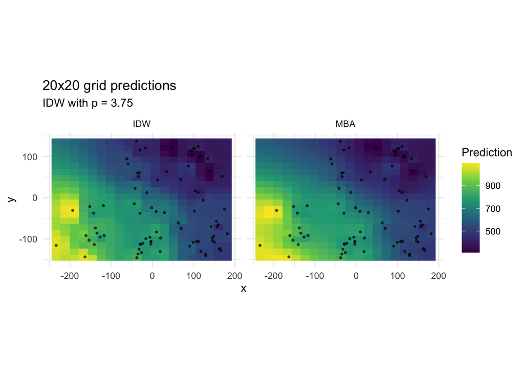

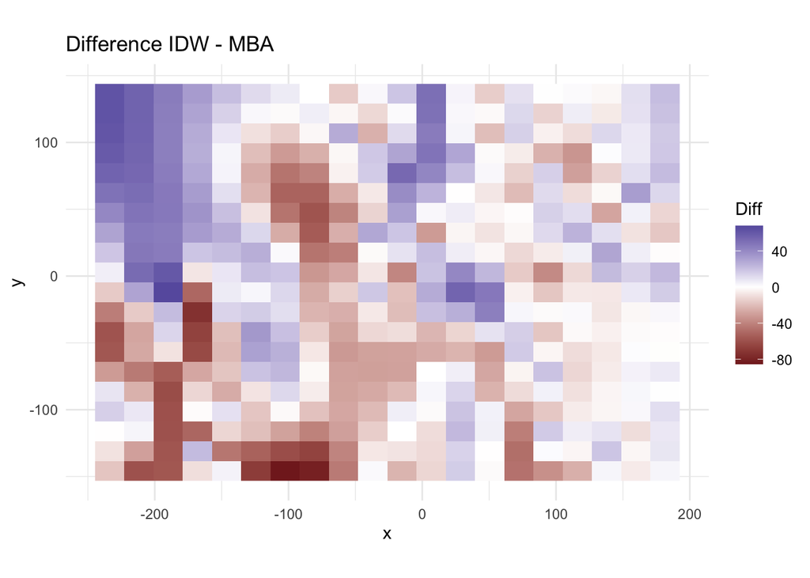

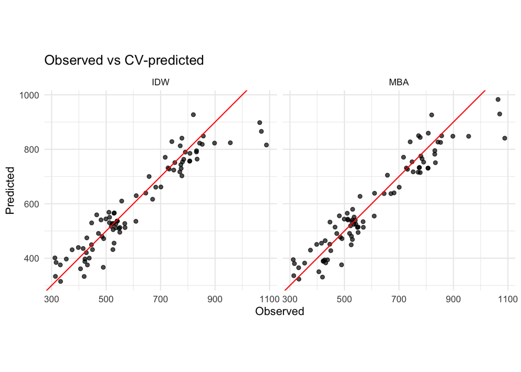

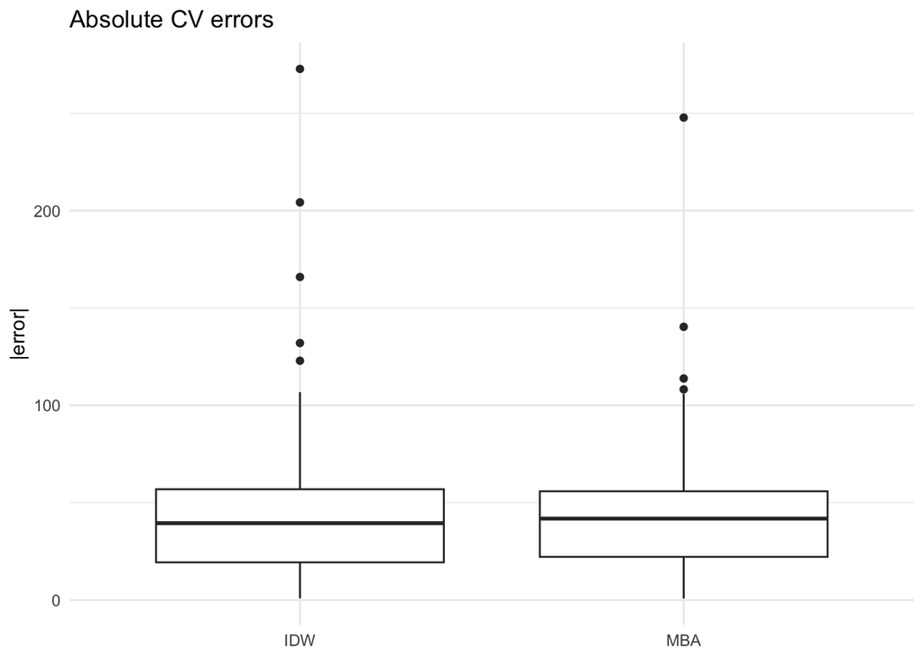

```r
res$plots$maps; res$plots$diff; res$plots$obs_pred; res$plots$errors
```

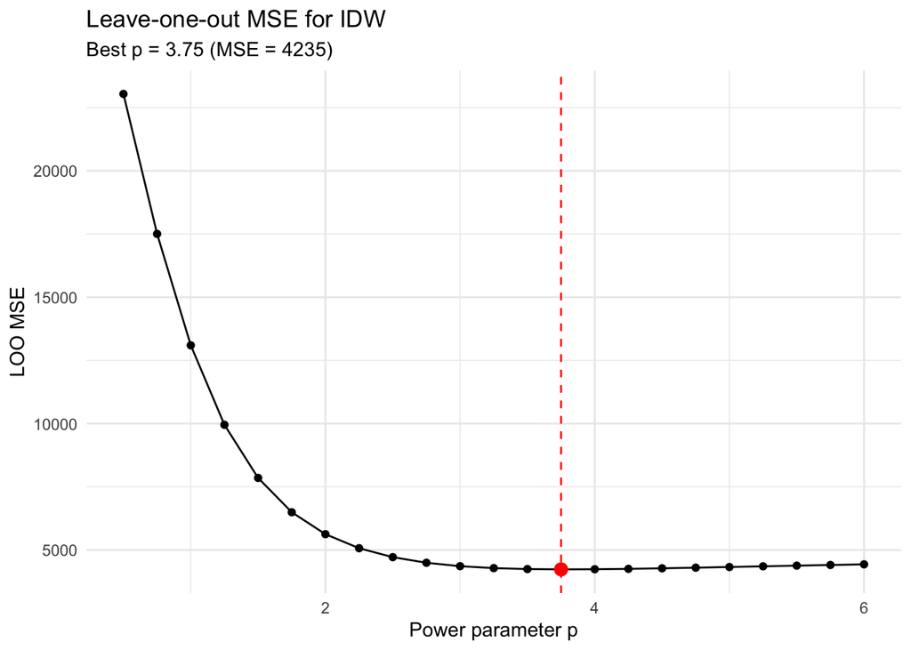

```r
res$p_selection_plot
```